# VInayJoshi_24DEC22

# Part 3: Prescriptive Stats

```python
df_2020 = df[df['Year'] == 2020]
# Group the data by "Place_in_India" and sum the values in the "Level 4" column
df_grouped_2020 = df_2020.groupby('Place_in_India')['Level 4'].sum()
df_all_2020 = df_grouped_2020.reset_index()
df_all_2020.insert(0, "Year", 2020, True)
df_all_2020.insert(1, "Rank", range(1, len(df_all_2020) + 1), True)


#No data for Year 2022 so calculating for 2022
df_2022 = df[df['Year'] == 2022]
df_grouped_2022 = df_2022.groupby('Place_in_India')['Level 4'].sum()
df_all_2022 = df_grouped_2022.reset_index()
df_all_2022.insert(0, "Year", 2022, True)
df_all_2022.insert(1, "Rank", range(1, len(df_all_2022) + 1), True)


df_agg = pd.concat([df_all_2020.head(3), df_all_2022.head(3)], axis=0)
df_agg
```

|  | Year | Rank | Place_in_India | Level 4 |
| --- | --- | --- | --- | --- |
| 0 | 2020 | 1 | Bengaluru | 3231524 |
| 1 | 2020 | 2 | Dehradun | 3685750 |
| 2 | 2020 | 3 | Hyderabad | 5156066 |
| 0 | 2022 | 1 | Bengaluru | 3752706 |
| 1 | 2022 | 2 | Dehradun | 2673864 |
| 2 | 2022 | 3 | Hyderabad | 8211936 |

```python
# Create a pivot table with the cities as the index, the years as the columns, and the sum of "Level 4" as the values
table = df.pivot_table(index=["Place_in_India", "Year"], values=["Level 1", "Level 2", "Level 3", "Level 4"], aggfunc="sum")

# Print the pivot table
for index, row in table.iterrows():
    table.at[index,('sumL2/sumL1')] = row[1]/row[0]
    table.at[index,('sumL3/sumL1')] = row[2]/row[0]
    table.at[index,('sumL4/sumL1')] = row[3]/row[0]
table = table.drop(["Level 1", "Level 2", "Level 3", "Level 4"], axis=1)
table
```

| Place_in_India | Year | sumL2/sumL1 | sumL3/sumL1 | sumL4/sumL1 |
| --- | --- | --- | --- | --- |
| Bengaluru | 2020 | 0.620010 | 0.573013 | 0.242929 |
|  | 2021 | 0.441488 | 0.390348 | 0.184470 |
|  | 2022 | 0.398947 | 0.375267 | 0.179285 |
| Dehradun | 2020 | 0.562625 | 0.410828 | 0.197959 |
|  | 2021 | 0.379406 | 0.304007 | 0.119051 |
|  | 2022 | 0.329035 | 0.349966 | 0.114622 |
| Hyderabad | 2020 | 0.616914 | 0.487160 | 0.235361 |
|  | 2021 | 0.419998 | 0.321613 | 0.162600 |
|  | 2022 | 0.457987 | 0.394942 | 0.132555 |
| Indore | 2020 | 0.681462 | 0.563541 | 0.267239 |
|  | 2021 | 0.464476 | 0.411337 | 0.182769 |
|  | 2022 | 0.520902 | 0.472407 | 0.135817 |
| Pune | 2020 | 0.545058 | 0.518644 | 0.187607 |
|  | 2021 | 0.322846 | 0.237307 | 0.099993 |
|  | 2022 | 0.361984 | 0.273714 | 0.084704 |

```python
table.sort_values("sumL4/sumL1", ascending=False)
```

| Place_in_India | Year | sumL2/sumL1 | sumL3/sumL1 | sumL4/sumL1 |
| --- | --- | --- | --- | --- |
| Indore | 2020 | 0.681462 | 0.563541 | 0.267239 |
| Bengaluru | 2020 | 0.620010 | 0.573013 | 0.242929 |
| Hyderabad | 2020 | 0.616914 | 0.487160 | 0.235361 |
| Dehradun | 2020 | 0.562625 | 0.410828 | 0.197959 |
| Pune | 2020 | 0.545058 | 0.518644 | 0.187607 |
| Bengaluru | 2021 | 0.441488 | 0.390348 | 0.184470 |
| Indore | 2021 | 0.464476 | 0.411337 | 0.182769 |
| Bengaluru | 2022 | 0.398947 | 0.375267 | 0.179285 |
| Hyderabad | 2021 | 0.419998 | 0.321613 | 0.162600 |
| Indore | 2022 | 0.520902 | 0.472407 | 0.135817 |
| Hyderabad | 2022 | 0.457987 | 0.394942 | 0.132555 |
| Dehradun | 2021 | 0.379406 | 0.304007 | 0.119051 |
|  | 2022 | 0.329035 | 0.349966 | 0.114622 |
| Pune | 2021 | 0.322846 | 0.237307 | 0.099993 |
|  | 2022 | 0.361984 | 0.273714 | 0.084704 |

### 3. Bottom 3 for "Level4 / Level1":

*Order: Ascending*  
**Bottom 3 for 2021:** *Pune* *Dehradun* *Hyderabad*

**Bottom 3 for 2022:** *Pune* *Dehradun* *Hyderabad*

**From the above table we can conclude that all the cases are same with Pune performing worst followed by Dehradun and then Hyderabad.**

```python
max(df[df["Level 4"] > 150000]['Place_in_India'])
```

```
'Pune'
```

### 4. “Level 4” value greater than 150000 most of the times:

```python
min(df[df['Type_of_Customers?'] == "Existing_Customer"]['Place_in_India'])
```

```
'Bengaluru'
```

### 5. least number of existing customers?:

**The Answer is "Bengaluru"**

# Part 4: Machine Learning:

```python
from sklearn.model_selection import train_test_split
from sklearn.linear_model import LogisticRegression
from xgboost import XGBClassifier
from sklearn.model_selection import train_test_split
import seaborn as sn
import matplotlib.pyplot as plt
```

```python
# Preprocessing data to feed into an Macine Learning model:
df2 = df.copy()
df2 = df2.drop(['Level 1', 'Level 2', 'Level 3'], axis=1)

# Encoding the Non-Numerical values:
from sklearn.preprocessing import LabelEncoder

# Create a dictionary to store the encoding maps
encoding_maps = {}

# Iterate over all the text columns
for col in df2.select_dtypes(include=['object']):
        # Encode the column using a LabelEncoder
        le = LabelEncoder()
        df2[col] = le.fit_transform(df2[col])
        # Store the encoding map in the dictionary
        encoding_maps[col] = le.classes_

# 1: January --- 12 : December
df2['Month'] = [(x+1) for x in df2.iloc[:]['Month']]

# Select the label column
labels = df2['Level 4']
features = df2.drop('Level 4', axis=1)
display(features, labels)
```

|  | Year | Month | Laptop/Desktop | Type_of_Customers? | Coming from | Place_in_India |
| --- | --- | --- | --- | --- | --- | --- |
| 0 | 2020 | 5 | 0 | 0 | 0 | 0 |
| 1 | 2020 | 5 | 0 | 0 | 0 | 2 |
| 2 | 2020 | 5 | 0 | 0 | 0 | 1 |
| 3 | 2020 | 5 | 0 | 0 | 0 | 3 |
| 4 | 2020 | 5 | 0 | 0 | 0 | 4 |
| ... | ... | ... | ... | ... | ... | ... |
| 2155 | 2022 | 3 | 1 | 1 | 2 | 0 |
| 2156 | 2022 | 3 | 1 | 1 | 2 | 2 |
| 2157 | 2022 | 3 | 1 | 1 | 2 | 1 |
| 2158 | 2022 | 3 | 1 | 1 | 2 | 3 |
| 2159 | 2022 | 3 | 1 | 1 | 2 | 4 |

2160 rows × 6 columns

```
0        17178
1        11916
2        19461
3       110667
4        46033
         ...
2155      1882
2156     16703
2157      2089
2158     78465
2159     19441
Name: Level 4, Length: 2160, dtype: int64
```

```python
# Train-test Split:
x_train,x_test,y_train,y_test = train_test_split(features, labels, test_size = 0.1, random_state = 7)
display(x_train, y_train)
```

|  | Year | Month | Laptop/Desktop | Type_of_Customers? | Coming from | Place_in_India |
| --- | --- | --- | --- | --- | --- | --- |
| 229 | 2020 | 1 | 1 | 1 | 0 | 4 |
| 1382 | 2021 | 3 | 0 | 0 | 0 | 1 |
| 34 | 2020 | 5 | 1 | 0 | 0 | 4 |
| 206 | 2020 | 1 | 0 | 1 | 2 | 2 |
| 37 | 2020 | 5 | 1 | 0 | 1 | 1 |
| ... | ... | ... | ... | ... | ... | ... |
| 211 | 2020 | 1 | 1 | 0 | 0 | 2 |
| 1603 | 2022 | 8 | 1 | 0 | 2 | 3 |
| 537 | 2020 | 12 | 1 | 1 | 2 | 1 |
| 1220 | 2021 | 12 | 0 | 1 | 1 | 0 |
| 175 | 2020 | 8 | 1 | 1 | 2 | 0 |

1944 rows × 6 columns

```
229     122740
1382     17429
34       40931
206       7345
37       14367
         ...
211       4578
1603      9831
537       7081
1220     46196
175       4140
Name: Level 4, Length: 1944, dtype: int64
```

```python
import random

# A set of default values for each month(0-january to 11-December) of the Year 2023
default = [(2023, int((_/50)+1) , random.randint(0, 1), random.randint(0, 1), random.randint(0, 2), random.randint(0, 4)) for _ in range(0,600)]
ds = pd.DataFrame(default, columns=x_test.columns)
ds
```

|  | Year | Month | Laptop/Desktop | Type_of_Customers? | Coming from | Place_in_India |
| --- | --- | --- | --- | --- | --- | --- |
| 0 | 2023 | 1 | 1 | 1 | 0 | 0 |
| 1 | 2023 | 1 | 0 | 0 | 1 | 4 |
| 2 | 2023 | 1 | 0 | 1 | 0 | 1 |
| 3 | 2023 | 1 | 0 | 0 | 2 | 2 |
| 4 | 2023 | 1 | 0 | 0 | 0 | 0 |
| ... | ... | ... | ... | ... | ... | ... |
| 595 | 2023 | 12 | 0 | 0 | 0 | 0 |
| 596 | 2023 | 12 | 1 | 1 | 2 | 2 |
| 597 | 2023 | 12 | 1 | 0 | 1 | 0 |
| 598 | 2023 | 12 | 0 | 0 | 2 | 4 |
| 599 | 2023 | 12 | 1 | 1 | 1 | 0 |

600 rows × 6 columns

```python
from sklearn.metrics import mean_absolute_percentage_error, mean_squared_error
ypred = []
def Model(xtrain=x_train, ytrain=y_train, xtest=x_test, ytest=y_test, metrics=False):
    model = XGBClassifier(eval_metric='merror')
    model.fit(xtrain,ytrain)
    ypred = model.predict(xtest)

    if metrics == True:
        mape = mean_absolute_percentage_error(ytest, ypred)
        rmse = np.sqrt(mean_squared_error(ytest, ypred))
        print(f"MAPE: {mape}, RMSE: {rmse}")
    return ypred
```

```python
''' Predictions for Year 2023 for 600 randomly created datapoints:
    Reason for choosing 600 Datapints: for 2020-2022 we have about 1944 datapoint,
    so an average of about 650 datapoints for each year. SO to match that we created
    a total of 600 datapoint for future prediction.
'''
predictions = Model(xtest=ds)
predictions
```

[output not shown]

[output cut: 52 more lines]

```python
df_2020_f, df_2020_l  = features[df2.Year == 2020], df2[df2.Year == 2020]['Level 4']
df_2021_f, df_2021_l  = features[df2.Year == 2021], df2[df2.Year == 2021]['Level 4']
df_2022_f, df_2022_l  = features[df2.Year == 2022], df2[df2.Year == 2022]['Level 4']

for x in [(df_2020_f, df_2020_l), (df_2021_f, df_2021_l), (df_2022_f, df_2022_l)]:
    Model(xtest=x[0], ytest=x[1], metrics=True)
```

```
MAPE: 0.8346466629136121, RMSE: 90121.12823597471
MAPE: 0.7982595349793671, RMSE: 88451.11783843128
MAPE: 1.0090725335476372, RMSE: 92570.29232635118
```

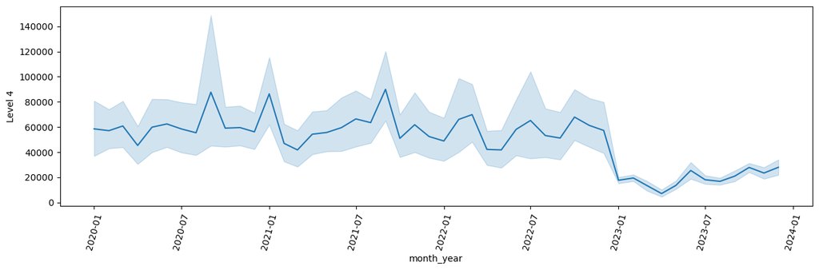

```python
# create a new column with the month and year values formatted as strings
ds['Level 4'] = predictions
df_plt = df2.copy()
df_plt = pd.concat([df_plt, ds], ignore_index=True)

df_plt['month_year'] = df_plt['Month'].astype(str).str.zfill(2)+ '-' +df_plt['Year'].astype(str)

df_plt['month_year'] = pd.to_datetime(df_plt['month_year'], format='%m-%Y')

# sort the DataFrame by the month_year column in ascending order
df_plt = df_plt.sort_values(by='month_year')


plt.figure(figsize=(15, 4))
# create the line plot
sn.lineplot(x='month_year', y=df_plt['Level 4'], data=df_plt)
plt.xticks(rotation=75)

# show the plot
plt.show()
```

```python
# Create a pivot table with the cities as the index, the years as the columns, and the sum of "Level 4" as the values
places_decoded = le.inverse_transform(df_plt["Place_in_India"])
table = df_plt.pivot_table(index=[places_decoded], columns="Year", values=["Level 4"], aggfunc="sum")

# Print the pivot table
# for index, row in table.iterrows():
#     display(row[1])
#     table.at[index,('Level 4')] = row[3]/row[0]
#     table.at[index,('Level 4')] = row[2]/row[0]
#     table.at[index,('Level 4')] = row[3]/row[0]
# table = table.drop(["Level 1", "Level 2", "Level 3", "Level 4"], axis=1)
table["diff"] = table["Level 4"][2023] - table["Level 4"][2022]
table
```

| Year | Level 4 2020 | Level 4 2021 | Level 4 2022 | Level 4 2023 | diff |
| --- | --- | --- | --- | --- | --- |
| Bengaluru | 3231524 | 3140030 | 3752706 | 1733909 | -2018797 |
| Dehradun | 3685750 | 2445091 | 2673864 | 2082056 | -591808 |
| Hyderabad | 5156066 | 7836311 | 8211936 | 1931170 | -6280766 |
| Indore | 20092071 | 17533698 | 15104408 | 3000648 | -12103760 |
| Pune | 11039977 | 12805835 | 11208722 | 2807079 | -8401643 |

*Looking at the above table we could conclude that in comparison to 2022, **Dehradun** in 2023 would do better than all the other Places*

# Part 5: Visualizations:

```python
# Iterate over all the text columns
for col in df.select_dtypes(include=['object']):
    if col == "Month":
        # Encode the column using a LabelEncoder
        le = LabelEncoder()
        df[col] = le.fit_transform(df[col])
        # Store the encoding map in the dictionary
        encoding_maps[col] = le.classes_

# 1: January --- 12 : December
df['Month'] = [(x+1) for x in df.iloc[:]['Month']]
df["Month"].unique()
```

```
array([ 5,  4,  8,  1,  9,  7,  6,  2, 12, 11, 10,  3])
```

```python
dfp = df.copy()
dfp['month_year'] = df['Month'].astype(str)+ '-' +df['Year'].astype(str).str.zfill(2)

dfp['month_year'] = pd.to_datetime(dfp['month_year'], format='%m-%Y')

# sort the DataFrame by the month_year column in ascending order
dfp = dfp.sort_values(by='month_year')
dfp
```

|  | Year | Month | Laptop/Desktop | Type_of_Customers? | Coming from | Place_in_India | Level 1 | Level 2 | Level 3 | Level 4 | month_year |
| --- | --- | --- | --- | --- | --- | --- | --- | --- | --- | --- | --- |
| 239 | 2020 | 1 | Laptop_Website | New_Customer | Unidentified_Sources | Pune | 201839.0 | 127107.0 | 37986 | 21543 | 2020-01-01 |
| 209 | 2020 | 1 | Desktop_Website | New_Customer | Unidentified_Sources | Pune | 182169.0 | 124750.0 | 43132 | 24175 | 2020-01-01 |
| 210 | 2020 | 1 | Laptop_Website | Existing_Customer | From LinkedIn | Bengaluru | NaN | NaN | 47007 | 12983 | 2020-01-01 |
| 211 | 2020 | 1 | Laptop_Website | Existing_Customer | From LinkedIn | Hyderabad | NaN | NaN | 18421 | 4578 | 2020-01-01 |
| 212 | 2020 | 1 | Laptop_Website | Existing_Customer | From LinkedIn | Dehradun | NaN | NaN | 34689 | 10200 | 2020-01-01 |
| ... | ... | ... | ... | ... | ... | ... | ... | ... | ... | ... | ... |
| 1953 | 2022 | 12 | Laptop_Website | Existing_Customer | From LinkedIn | Indore | NaN | NaN | 79808 | 26288 | 2022-12-01 |
| 1952 | 2022 | 12 | Laptop_Website | Existing_Customer | From LinkedIn | Dehradun | NaN | NaN | 26588 | 7986 | 2022-12-01 |
| 1951 | 2022 | 12 | Laptop_Website | Existing_Customer | From LinkedIn | Hyderabad | NaN | NaN | 79805 | 24035 | 2022-12-01 |
| 1949 | 2022 | 12 | Desktop_Website | New_Customer | Unidentified_Sources | Pune | 154252.0 | 58434.0 | 22978 | 11343 | 2022-12-01 |
| 1979 | 2022 | 12 | Laptop_Website | New_Customer | Unidentified_Sources | Pune | 321848.0 | 123688.0 | 48452 | 18697 | 2022-12-01 |

2160 rows × 11 columns

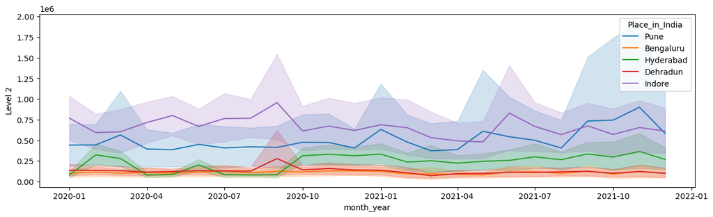

```
' Insights:\n    For Year 2020, Indore was the ebst performing Place in India. As we move into 2021, \n    Pune has been competing with Indore and outperforms others in 2nd half of the year.\n'
```

```python
# 1.
# filter the DataFrame to only include rows with Year values of 2020 or 2021
plt.figure(figsize=(15, 4))
sn.lineplot(x='month_year', y='Level 2', hue='Place_in_India', data=dfp[dfp['Year'].isin([2020, 2021])])
plt.show()
''' Insights:
    For Year 2020, Indore was the ebst performing Place in India. As we move into 2021,
    Pune has been competing with Indore and outperforms others in 2nd half of the year.
'''
```

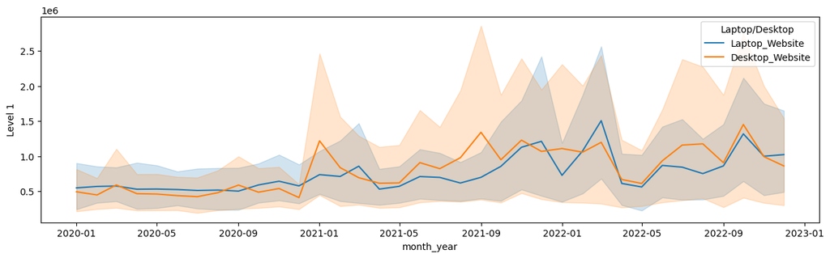

```
' Insights:\n    We have same nUmber of Users from both the sources.\n'
```

```python
# 2
plt.figure(figsize=(15, 4))
sn.lineplot(x='month_year', y='Level 1', hue='Laptop/Desktop', data=dfp)
plt.show()
''' Insights:
    We have same nUmber of Users from both the sources.
'''
```

[figure not shown]

```
' Insights:\n    Most of the customers have landed drectly to the website, indicating good marketting campaigns. \n'
```

```python
# 3
plt.figure(figsize=(15, 4))
sn.lineplot(x='month_year', y='Level 2', hue='Coming from', data=dfp)
plt.show()
''' Insights:
    Most of the customers have landed drectly to the website, indicating good marketting campaigns.
'''
```

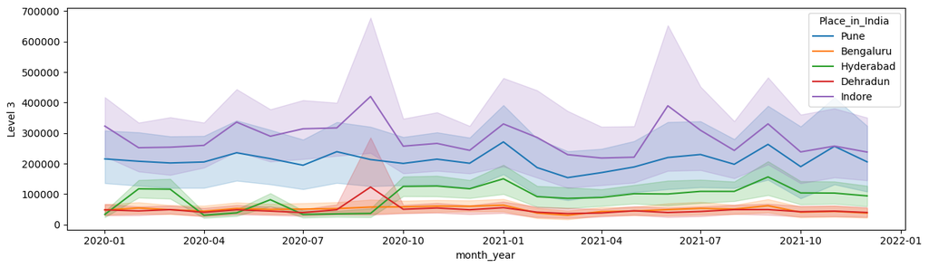

```
' Insights:\n    We can conclude that most most of our customers belong to INdore and Pune.\n'
```

```python
# 5
plt.figure(figsize=(15, 4))
sn.lineplot(x='month_year', y='Level 3', hue='Place_in_India', data=dfp[dfp['Year'].isin([2020, 2021])])
plt.show()
''' Insights:
    We can conclude that most most of our customers belong to INdore and Pune.
'''
```

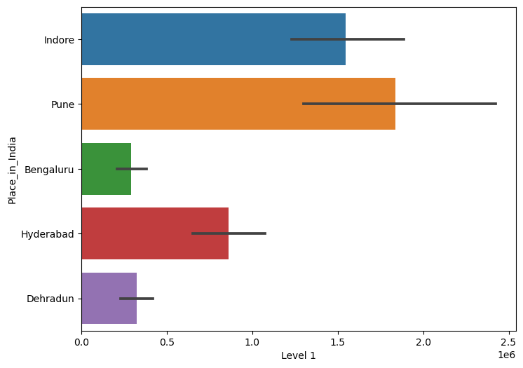

```python
# 6
plt.figure(figsize=(8, 6))
sn.barplot(x='Level 1', y='Place_in_India',data=dfp[dfp['Year'].isin([2022])])

plt.show()
```

```python
dfpp = dfp[dfp["Year"] == 2022]
dfpp[dfpp["Type_of_Customers?"] == "Existing_Customer"]["Level 1"].max()
# Result of this code demostrates why we dont have any data in existing customer section.
```

```
nan
```

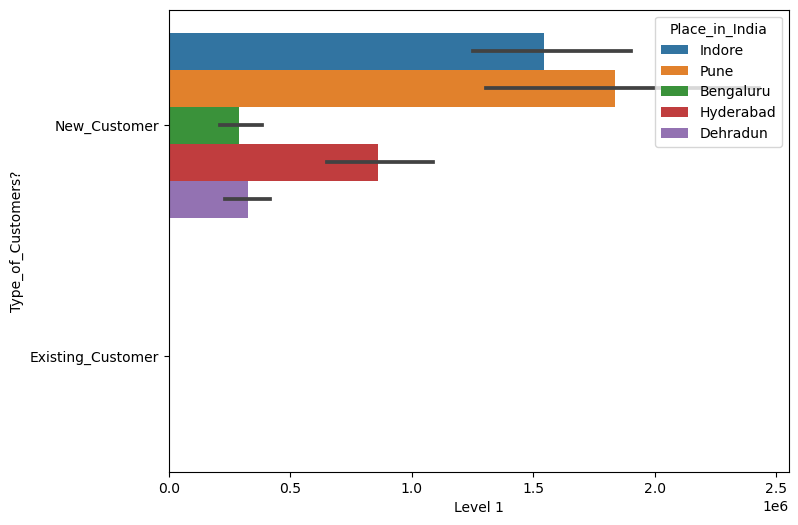

```python
# 6
plt.figure(figsize=(8, 6))
sn.barplot(x='Level 1', y='Type_of_Customers?', hue="Place_in_India", data=dfp[dfp['Year'].isin([2022])])
plt.show()
```

# Part 6: About the Projects:

### Title: Comparison of Machine Learning Algorithms for Predicting Bioactivity of PKM2 Modulators

*In this ongoing project, I have been working with my professor to develop machine learning algorithms for predicting the biological activity of various molecular targets. This research has the potential to be a significant advancement in cancer research, as the protein we are studying is a key target for drug discovery. Specifically, we have used a range of machine learning models and compared their performance in terms of accuracy and precision. To optimize the models' performance, we have applied various feature selection techniques to identify the most relevant features from a dataset of 1886 bioactive descriptors. Working with biological data can be challenging, as it often requires extensive cleaning, selection, and transformation. While we have achieved some promising results so far, I will not able to share specific details at this time due to the confidential nature of the project.*

### Title: Predicting Parkinson's Disease Outcomes Using Machine Learning Algorithms

*In this side project, I applied the XGBoost algorithm to predict outcomes in Parkinson's disease data. I computed the accuracy of the model and generated visualizations to help understand the results. I also identified the most important features that contributed to the prediction. By using machine learning techniques, I was able to gain insights into the factors that may influence the course of the disease and potentially inform treatment decisions. Overall, this project was a valuable learning opportunity and allowed me to explore the potential of machine learning in the context of healthcare data.*</i>

# Part 7: Time Management:

If selected for this full-time internship, I am committed to maximizing my productivity and delivering high-quality work. To do this, I plan to prioritize my tasks and manage my time effectively by setting clear goals and allocating my time accordingly. I will also break larger tasks into smaller ones to make them more manageable. I am confident in my ability to effectively manage my time, as I have a strong track record in this area and the next six months to focus solely on this internship without any other commitments. I am grateful for the opportunity to intern with your company and am excited to contribute my skills and knowledge to your team. Thank you for considering me for this opportunity.